# Corpus-based approach meets LFG: Puzzling voice alternation in Indonesian

Gede Primahadi Wijaya Rajeg, I Made Rajeg, I Wayan Arka

# Introduction

This paper describes a novel approach to the study of grammatical voice (hereafter, voice) in Indonesian by providing fresh, corpus-based evidence that voice alternations for a given verb, especially between active and passive, are not always a meaning-preserving phenomenon (Kroeger 2005: 271) (cf. §@ref(goals)). The idea of “meaning-preserving” in active-passive alternation is that active and passive clauses, based on the same verb, should “describe the same kind of event” (Kroeger 2005: 271) or “conveying propositions with the same truth values” (Zúñiga & Kittilä 2019: 1). Consider these Indonesian examples.

The base verb is *kena-kan* (derived from the verbal root *kena* ‘hit; get into contact with’) and it conveys the event of ‘wearing a clothing’ both in its active form with *meN-* prefix (1) (hereafter AV) and in passive with *di-* prefix (2) (hereafter PASS). Looking at only these two sentences, the meaning-preserving status is indeed hold for voice alternation (of *kenakan* in AV and PASS). Based on quantitative corpus analysis on the usage of verbs derived from *kena* (see §@ref(aims))), we argue for the following two empirical evidence (§@ref(corpus-results)):

- Certain sense of a given verb is significantly more frequently expressed in one voice type than in the other. This suggests that certain sense may be strongly and conventionally associated with certain form of voice (Figure @ref(fig:mengenai-dikenai-plot) and Figure @ref(fig:mengenakan-dikenakan-plot)).
- Certain sense of a given verb can be directly constructed in one voice, in this case PASS, with no corresponding form in the other voice, in this case AV (§@ref(kenai-av-pass)). This indicates that (i) voice alternation should be relativised to certain sense of a verb such that one sense of a verb may not enter voice alternation, and that (ii) PASS form of a verb in a given sense is not always derived from its AV counterpart; hence not showing a meaning-preserving property (Figure @ref(fig:mengenai-dikenai-plot)).

## Related works and problem statement

Corpus-based, quantitative research on voice in Indonesian languages particularly focus on discourse-pragmatic factors (e.g. topicality of patient, transitivity of the event, grounding) that influence voice selection in discourse (for Indonesian, see Wouk 1996; Wouk 1989; for Balinese, Pastika 1999; see also McDonnell 2016 who considers additional factors unexplored in previous works, using informal, face-to-face interaction data in Besemah)[^1]. Despite the extensive research on voice in Indonesian context, very little attention has been paid to the role of verb senses and their interaction with voice type of the verb. The question is whether voice alternation for a given verb stem interacts with the semantic potentials of the verb, given a verb can be polysemous.

McDonnell’s (2016: 242–244) *Collostructional Analysis* (Stefanowitsch 2013) in Besemah has shown that certain verbal roots more frequently occur in agentive voice than in patientive voice (in Besemah’s symmetrical voice system) (see Gries & Stefanowitsch 2004 for a similar study for voice alternation in English), and found that such degree of attraction plays a role in voice selection, in addition to the other factors (e.g. discourse transitivity and clausal mood). In line with our goal, McDonnell (2016: 250) notes an unexplored factor in voice selection, namely the possibility of semantic properties of the verbal root to account for strong preference of the verb to occur in AV or PASS construction.

## Object of the study

We focus on verbs derived from the verbal root *kena* ‘hit; get into contact with’, which is lexically Patient-oriented (cf. (3)), meaning that the syntactic subject of *kena* is associated with Patient-like role. *Kena* is also associated with negative affectedness on the subject[^2].

We studied derivatives of *kena* with two transitive suffixes, namely -*kan* (*kena**kan*) and -*i* (*kena**i*); these suffixes can express applicative/causative reading, depending on the roots (see, e.g., Arka et al. 2009, amongst others). The stems *kenakan* and *kenai* can then take the *meN-* and *di-* prefixes that respectively encode AV and PASS voice types. These verbs show puzzling behaviour, as discussed with key examples in (4) and (5), in relation to their meanings as expressed in certain voice forms.

The original example in (4) is with the -*i* form *mengenai* as the main predicate in AV, expressing the ‘physical hit or touch’ sense. We put the AV -*kan* form *mengenakan* to indicate that it cannot alternate with *mengenai* to convey the same ‘physical hit or touch’ sense expressed by *mengenai*. In contrast, example (5) intends to show that the -*i* and -*kan* verbs can alternate in the PASS in expressing ‘subject to’ sense. In other words, the PASS *dikenai* and *dikenakan* can equally express ‘subject to’ sense. These behaviours are summarised in Figure @ref(fig:kena-initial-distribution).

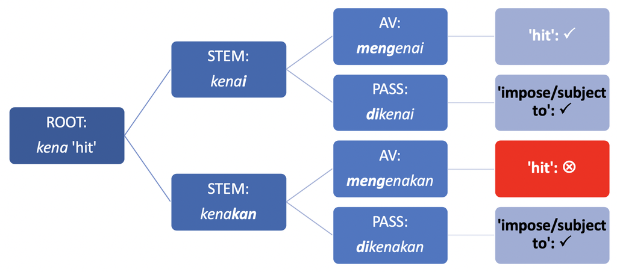

## Aims

Our corpus-based study seeks to determine whether different senses/meanings of verbal stems *kenakan* and *kenai* find similar distribution across AV and PASS, such that a given sense of the verbs exhibit strong attraction to a given voice type (§@ref(corpus-results)). We scale up the amount of data that we analysed because, as we shall see, relying on a pair of examples (as in (1) and (2)) fail to capture asymmetric distribution of senses for a given verb in different voice types. Such an inquiry touches on the idea of meaning-preserving property of voice alternation for a given verb (see §@ref(intro)).

# Data source

We then categorised the senses of each verb based on two heuristic guidelines: The description of the verb in the Big Dictionary of Indonesian language, and more importantly the semantic types of arguments co-occur with the verb. For instance, the ‘subject to/impose’ sense of *dikenakan* can be inferred from its co-occurrences with obligation-related nominal arguments and context (7). Meanwhile, the ‘wear (clothing)’ sense of *dikenakan* can be inferred from its co-occurrence with clothing/accessories-related arguments and context (8).

Moreover, the primary, physical ‘hit’ or ‘come into touch’ sense of *kenai* can be inferred when direct causation is performed from the agent to the patient arguments, which predominantly involve parts of the body; (4) in §@ref(aims) and (9) below are the typical context. Meanwhile, *kenai* can also encode invisible affectedness sense in the medical and mental domain where certain organ or parts of the body is affected by disease (10), or someone is mentally affected (11).

# Corpus-based results

## Senses for *kenai* in PASS and AV

The most frequent senses for *kenai* is ‘hit; contact; touch’ (N = 262; 61.94%), followed by ‘subject to/imposed’ (N = 124; 29.31%) and disease/mental ‘affect’ (N = 37; 8.75%). Figure @ref(fig:mengenai-dikenai-plot) visualises the distribution of these senses in PASS and AV forms of *kenai*. The height of the bars represent percentages, with the raw numbers are given inside the bars.

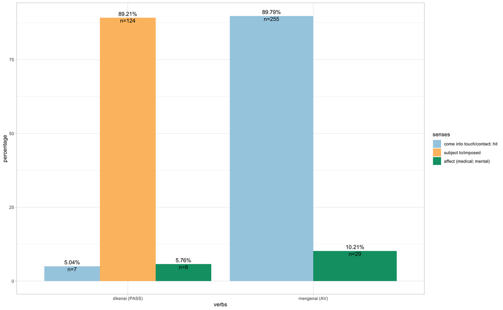

It is clear that the distribution of senses for *kenai* is not equal across voice. The primary, physical sense of *kenai* ‘hit; come into touch/contact’ can indeed occur in PASS and AV, but its proportion is much greater to be expressed in AV (89.79 %) than in PASS (5.04%). Slight distributional difference could as well be seen in the least frequent sense of ‘medical/mental affect’.

Figure @ref(fig:mengenai-dikenai-plot) also reveals an empirical evidence that voice alternation is not always a meaning-preserving phenomenon. It is shown by the absence of ‘subject to/be imposed’ sense in AV; this sense is only found in PASS and intriguingly is the most frequent of all senses of *kenai* in PASS. This indicates that ‘subject to/be imposed’ is directly constructed and conventionalised in PASS. Hence, it should not be regarded as a derivative of an (underlying) AV form, which is empirically not attested for this sense in the corpus.

A chi-square test for independence suggests that the asymmetric distribution of senses for *kenai* in PASS and AV (i) cannot be due to chance (i.e. it is statistically significant) (*X*<sup>2</sup> = 363.699, *df* = 2, *p*<sub>two-tailed</sub> < 0.001) and (ii) demonstrates a highly strong effect size (Cramer’s *V* = 0.927)[^3]. The effect is indicated by the significantly strong preference of ‘hit; come into touch/contact’ sense to be expressed in AV (i.e. it has positive residuals for AV) and of ‘subject to/be imposed’ sense in PASS without AV occurrence[^4].

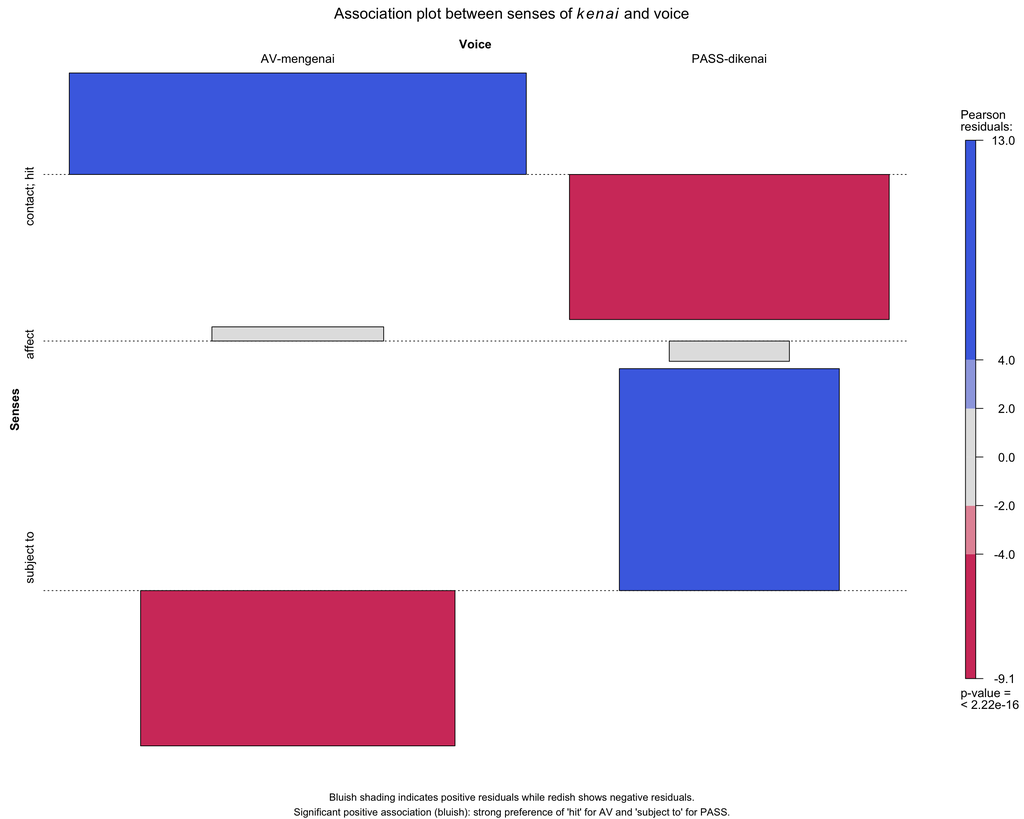

## Senses for *kenakan* in PASS and AV

The lion share of the usage occurrences of *kenakan* convey the ‘wear; put on’ sense (N = 1,182; 77.31%), followed by ‘subject to/imposed’ (N = 301; 19.69%) and other senses (N = 46; 3.01%). Figure @ref(fig:mengenakan-dikenakan-plot) visualises the distribution of these senses in PASS and AV forms of *kenakan*.

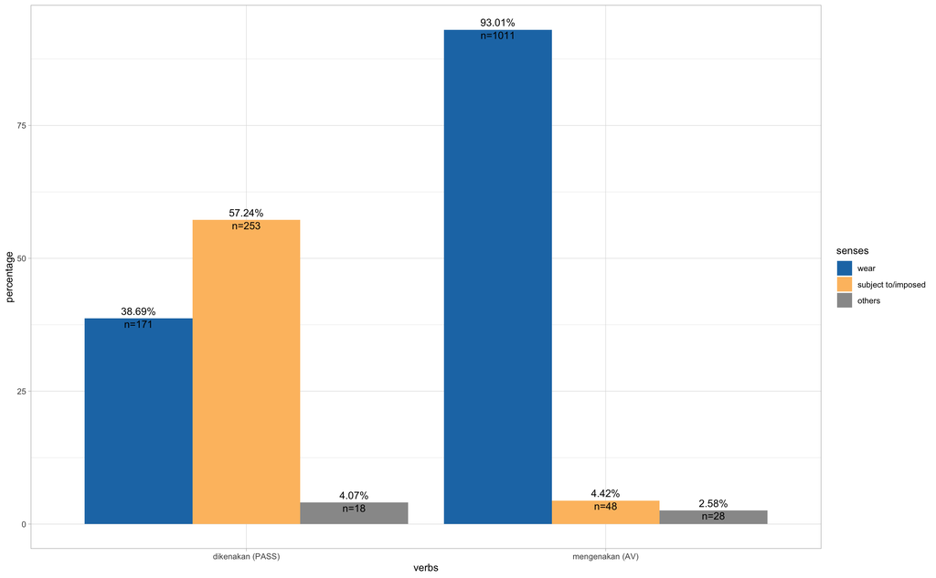

Similar trend of distributional asymmetry can be seen from Figure @ref(fig:mengenakan-dikenakan-plot), as observed previously in Figure @ref(fig:mengenai-dikenai-plot). The proportion of the two most frequent senses for *kenakan* (i.e. ‘wear’ and ‘subject to/be imposed’) differs in AV and PASS. ‘Wear; put on’, while indeed attested in AV and PASS, is much more frequently expressed in AV (93.01%) than in PASS (38.69%). In contrast, ‘subject to/be imposed’ is expressed much more frequently in PASS (57.24%) than in AV (4.42%).

The chi-square test for independence suggests that this asymmetric distribution is statistically significant (*X*<sup>2</sup> = 567.676, *df* = 2, *p*<sub>two-tailed</sub> < 0.001) and has a strong effect size (Cramer’s *V* = 0.609). The effect is shown by the significantly strong preference of ‘wear’ to be encoded in AV (but dispreferred in PASS) and of ‘subject to/imposed’ in PASS (but dispreferred in AV).

Considering the PASS of the two stems *kenai* (§@ref(kenai-av-pass)) and *kenakan*, they exhibit similar semantic traits, namely most predominantly used in expressing the ‘subject to/be imposed’ sense. This sense is so frequent for the PASS of *kenai* and *kenakan* that it is unsurprisingly interchangeably expressed by these two PASS forms, as pointed out in §@ref(aims) in example (5). Furthermore, the ‘others’ category for the AV *mengenakan* include 6 tokens of physical ‘hit/touch’ sense (12), which we canceled out for this verb in (4) based on our intuitive, native-speaker judgment.

12. pukulan itu mengenakan tepat di pundaknya (900892)

Corpus analysis reveals both (i) the attestation of this ‘hit/touch’ sense with *mengenakan* and (i) its statistical dispreference for *mengenakan* compared to its strong association with *mengenai* (see Figure @ref(fig:mengenai-dikenai-plot)).

Viewed from the perspective of usage-based, cognitive linguistics, which considers the important role of frequency in the emergence, representation, and processing of linguistic units, our findings call into question the implicitly presumed equal status of PASS and AV alternation for a given verb stem, in terms of their conventionality and usage frequency in conveying certain sense. Previous usage-based study on constructional alternation (e.g. Locative alternation of SPRAY/LOAD verbs) in Russian also suggest asymmetric distribution of certain construction type in relation to aspectual prefixes attached to the verb (Sokolova 2012).

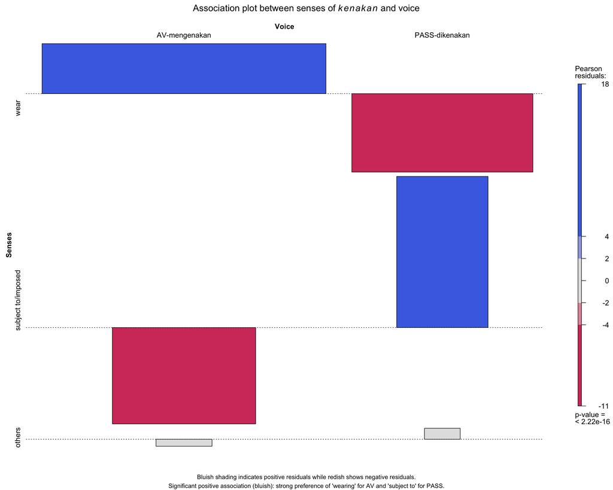

# References

Arka, I Wayan, Mary Dalrymple, Meladel Mistica, Suriel Mofu, Avery D. Andrews & Jane Simpson. 2009. A linguistic and computational morphosyntactic analysis for the applicative *-i* in indonesian. In Miriam Butt & Tracy Holloway King (eds.), *Proceedings of the LFG09 conference*. CSLI Publications.

Goldhahn, Dirk, Thomas Eckart & Uwe Quasthoff. 2012. Building large monolingual dictionaries at the leipzig corpora collection: From 100 to 200 languages. In *Proceedings of the 8th language resources and evaluation conference (LREC) 2012*, 759–765. Istanbul. http://www.lrec-conf.org/proceedings/lrec2012/pdf/327_Paper.pdf (5 March, 2014).

Gries, Stefan Th. & Anatol Stefanowitsch. 2004. Extending collostructional analysis: A corpus-based perspective on ’alternations’. *International Journal of Corpus Linguistics* 9(1). 97–129.

Kroeger, Paul R. 2005. *Analyzing Grammar: An Introduction*. Cambridge: Cambridge University Press.

McDonnell, Bradley. 2016. *Symmetrical voice constructions in Besemah: A usage-based approach*. Santa Barbara, USA: University of California, Santa Barbara PhD dissertation. https://www.alexandria.ucsb.edu/lib/ark:/48907/f3mp53bw (5 January, 2020).

Pastika, I Wayan. 1999. *Voice selection in Balinese narrative discourse*. Canberra, A.C.T., Australia: The Australian National University PhD thesis.

Quasthoff, Uwe & Dirk Goldhahn. 2013. *Indonesian corpora*. Leipzig, Germany: Abteilung Automatische Sprachverarbeitung, Institut für Informatik, Universität Leipzig. http://asvdoku.informatik.uni-leipzig.de/corpora/data/uploads/corpus-building-vol7-ind.pdf (26 July, 2015).

Stefanowitsch, Anatol. 2013. Collostructional analysis. In Thomas Hoffmann & Graeme Trousdale (eds.), *The oxford handbook of construction grammar* (Oxford Handbooks Online), 290–306. Oxford: Oxford University Press. https://doi.org/10.1093/oxfordhb/9780195396683.013.0016.

Wouk, Fay. 1989. *The impact of discourse on grammar: Verb morphology in spoken Jakarta Indonesian*. United States – California: University of California, Los Angeles Ph.D. (12 October, 2018).

Wouk, Fay. 1996. Voice in Indonesian Discourse and its Implications for Theories of the Development of Ergativity. *Studies in Language* 20(2). 361–410. https://doi.org/10.1075/sl.20.2.05wou (23 July, 2020).

Zúñiga, Fernando & Seppo Kittilä. 2019. *Grammatical Voice*. 1st edn. Cambridge ; New York: Cambridge University Press. https://doi.org/10.1017/9781316671399 (18 May, 2020).